# Estimación Costes Stock: CatBoost vs Naive

Este notebook implementa el análisis de costes de inventario comparando:

- **Modelo CatBoost**: Predicciones del mejor modelo ML
- **Modelo Naive**: Media móvil de 7 días

Se utiliza la fórmula de Yamazaki (2015) para calcular el stock de seguridad: $$SS = Z \times \sigma \times \sqrt{L}$$

Donde:

- $Z$: Factor de servicio (1.645 para 95%). Distribución normal estándar inversa para probailidad dada (%Nivel del servicio)
- $\sigma$: Desviación estándar del error (RMSE)
- $L$: Lead time (días de aprovisionamiento), Se toman los días entre pedidos más los días de lead time

**Referencia**: Yamazaki, Y. (2015). DOI: https://doi.org/10.1080/00207543.2015.1076179

# Importaciones

```python
import os
import pandas as pd
import numpy as np
from sklearn.metrics import mean_squared_error
from scipy.stats import norm
import warnings
warnings.filterwarnings('ignore')

# Detectar si estamos en Google Colab
try:
    import google.colab
    IN_COLAB = True
except ImportError:
    IN_COLAB = False

# Configurar el directorio de trabajo según el entorno
if IN_COLAB:
    os.chdir('TFMDS')
else:
    # Detectar si estamos en Codespaces o VS Code local
    if os.path.exists('/workspaces/TFMDS'):
        # Entorno Codespaces
        os.chdir('/workspaces/TFMDS')
    else:
        # En VS Code local, nos movemos al directorio raíz del proyecto
        # Usa raw string para evitar errores de escape en rutas Windows
        current_dir = r'C:\Users\jmora\Documents\TFMDS'
        os.chdir(current_dir)

# OPCIONAL: Para verificar que estás en la ruta correcta y ver las carpetas
print("Directorio de trabajo actual:", os.getcwd())
```

```
Directorio de trabajo actual: C:\Users\jmora\Documents\TFMDS
```

# Parámetros

```python
# Parámetros globales
TASA_ALMACENAMIENTO = 0.05    # 5% del valor del producto
NIVEL_SERVICIO = 0.95               # 95% de nivel de servicio
Z_SCORE = norm.ppf(NIVEL_SERVICIO)  # Factor Z para %NIVEL_SERVICIO5 de confianza ppf = inversa de la CDF normal estándar

print("Configuración cargada")
print(f"Nivel de servicio: {NIVEL_SERVICIO*100}%")
print(f"Z-score: {Z_SCORE}")
print(f"Tasa almacenamiento anual: {TASA_ALMACENAMIENTO*100}%")
```

```
Configuración cargada
Nivel de servicio: 95.0%
Z-score: 1.6448536269514722
Tasa almacenamiento anual: 5.0%
```

# Carga de Datos

```python
# Cargar predicciones de CatBoost
df_test = pd.read_csv('datos/df_test_catboost.csv', sep=';', decimal=',')
print(f"Datos de test cargados: {df_test.shape}")
print(f"Columnas: {df_test.columns.tolist()}")

# Cargar datos de ciclo de aprovisionamiento
df_ciclos = pd.read_csv('datos/DatosCicloAprovisionamiento.csv', sep=';', decimal=',')
print(f"\nDatos de ciclos: {df_ciclos.shape}")
print(f"Columnas: {df_ciclos.columns.tolist()}")

# Cargar precios medios
df_precios = pd.read_csv('datos/DatosPrecioMedio.csv', sep=';', decimal=',')
# Convertir precio de formato europeo (coma) a float
if df_precios['eurPrecioMedio'].dtype == 'object':
    df_precios['eurPrecioMedio'] = df_precios['eurPrecioMedio'].str.replace(',', '.').astype(float)
print(f"\nDatos de precios: {df_precios.shape}")
print(f"Columnas: {df_precios.columns.tolist()}")

# Vista previa
print("\nPrimeras filas de df_test:")
display(df_test.head())
print("\nPrimeras filas de df_ciclos:")
display(df_ciclos.head())
print("\nPrimeras filas de df_precios:")
display(df_precios.head())
```

```
Datos de test cargados: (23244, 4)
Columnas: ['idSecuencia', 'producto', 'udsVenta', 'udsVentaPred']

Datos de ciclos: (1000, 3)
Columnas: ['producto', 'diasEntrePedidos', 'diasLeadtime']

Datos de precios: (1001, 2)
Columnas: ['producto', 'eurPrecioMedio']

Primeras filas de df_test:
```

|  | idSecuencia | producto | udsVenta | udsVentaPred |
| --- | --- | --- | --- | --- |
| 0 | 2024-10-07 | 1 | 2 | 7.909209 |
| 1 | 2024-10-08 | 1 | 0 | 7.026752 |
| 2 | 2024-10-09 | 1 | 5 | 5.903247 |
| 3 | 2024-10-10 | 1 | 49 | 6.543139 |
| 4 | 2024-10-11 | 1 | 7 | 11.997252 |

```
Primeras filas de df_ciclos:
```

|  | producto | diasEntrePedidos | diasLeadtime |
| --- | --- | --- | --- |
| 0 | 1 | 14 | 15 |
| 1 | 2 | 14 | 15 |
| 2 | 3 | 14 | 15 |
| 3 | 4 | 14 | 15 |
| 4 | 5 | 14 | 15 |

```
Primeras filas de df_precios:
```

|  | producto | eurPrecioMedio |
| --- | --- | --- |
| 0 | 1.0 | 68.730000 |
| 1 | 2.0 | 148.330000 |
| 2 | 3.0 | 169.000000 |
| 3 | 4.0 | 0.604383 |
| 4 | 5.0 | 4.553314 |

# Preparación de Datos

```python
# Preparar el dataframe con todas las columnas necesarias
# Convertir idSecuencia a datetime
df_test['fecha'] = pd.to_datetime(df_test['idSecuencia'])

# Merge con ciclos de aprovisionamiento
df_test = df_test.merge(df_ciclos[['producto', 'diasEntrePedidos', 'diasLeadtime']],
                         on='producto', how='left')

# Calcular ciclo total de aprovisionamiento (L en la fórmula)
df_test['ciclo_aprovisionamiento'] = df_test['diasEntrePedidos'] + df_test['diasLeadtime']

# Merge con precios
df_test = df_test.merge(df_precios[['producto', 'eurPrecioMedio']],
                         on='producto', how='left')

# Verificar datos faltantes
print("Datos faltantes por columna:")
print(df_test.isnull().sum())
print(f"\nTotal de registros: {len(df_test)}")
print(f"Productos únicos: {df_test['producto'].nunique()}")
print(f"Rango de fechas: {df_test['fecha'].min()} a {df_test['fecha'].max()}")

# Vista previa
display(df_test)
```

```
Datos faltantes por columna:
idSecuencia                0
producto                   0
udsVenta                   0
udsVentaPred               0
fecha                      0
diasEntrePedidos           0
diasLeadtime               0
ciclo_aprovisionamiento    0
eurPrecioMedio             0
dtype: int64

Total de registros: 23244
Productos únicos: 894
Rango de fechas: 2024-10-07 00:00:00 a 2024-11-05 00:00:00
```

|  | idSecuencia | producto | udsVenta | udsVentaPred | fecha | diasEntrePedidos | diasLeadtime | ciclo_aprovisionamiento | eurPrecioMedio |
| --- | --- | --- | --- | --- | --- | --- | --- | --- | --- |
| 0 | 2024-10-07 | 1 | 2 | 7.909209 | 2024-10-07 | 14 | 15 | 29 | 68.73 |
| 1 | 2024-10-08 | 1 | 0 | 7.026752 | 2024-10-08 | 14 | 15 | 29 | 68.73 |
| 2 | 2024-10-09 | 1 | 5 | 5.903247 | 2024-10-09 | 14 | 15 | 29 | 68.73 |
| 3 | 2024-10-10 | 1 | 49 | 6.543139 | 2024-10-10 | 14 | 15 | 29 | 68.73 |
| 4 | 2024-10-11 | 1 | 7 | 11.997252 | 2024-10-11 | 14 | 15 | 29 | 68.73 |
| ... | ... | ... | ... | ... | ... | ... | ... | ... | ... |
| 23239 | 2024-10-31 | 1000 | 0 | 1.264586 | 2024-10-31 | 14 | 2 | 16 | 40.73 |
| 23240 | 2024-11-01 | 1000 | 0 | 0.190684 | 2024-11-01 | 14 | 2 | 16 | 40.73 |
| 23241 | 2024-11-02 | 1000 | 0 | 1.376287 | 2024-11-02 | 14 | 2 | 16 | 40.73 |
| 23242 | 2024-11-04 | 1000 | 7 | 1.311637 | 2024-11-04 | 14 | 2 | 16 | 40.73 |
| 23243 | 2024-11-05 | 1000 | 2 | 1.513267 | 2024-11-05 | 14 | 2 | 16 | 40.73 |

23244 rows × 9 columns

# Modelo Naive: Media Móvil 7 días

Implementación el modelo baseline utilizando una media móvil de 7 días como predicción.

```python
# Ordenar por producto y fecha para calcular media móvil
df_test = df_test.sort_values(['producto', 'fecha']).reset_index(drop=True)

# Crear predicción Naive: media móvil de 7 días
df_test['udsVentaPred_Naive'] = df_test.groupby('producto')['udsVenta'].transform(
    lambda x: x.rolling(window=7, min_periods=1).mean().shift(1)
)


# Para los primeros días sin histórico suficiente, usar la media general del producto
df_test['udsVentaPred_Naive'] = df_test.groupby('producto')['udsVentaPred_Naive'].transform(
    lambda x: x.fillna(x.mean())
)

print("Predicciones Naive calculadas")
print(f"Valores nulos en Naive: {df_test['udsVentaPred_Naive'].isnull().sum()}")

# Comparativa de predicciones
print("\nEstadísticas de predicciones:")
print(df_test[['udsVenta', 'udsVentaPred', 'udsVentaPred_Naive']].describe())

display(df_test[['fecha', 'producto', 'udsVenta', 'udsVentaPred', 'udsVentaPred_Naive']].head(20))
```

```
Predicciones Naive calculadas
Valores nulos en Naive: 0

Estadísticas de predicciones:
           udsVenta  udsVentaPred  udsVentaPred_Naive
count  23244.000000  23244.000000        23244.000000
mean       1.632851      1.615016            1.656210
std        2.768287      1.345529            1.860696
min        0.000000     -0.841746            0.000000
25%        0.000000      0.727191            0.285714
50%        0.000000      1.237118            1.000000
75%        2.000000      2.084822            2.285714
max       49.000000     15.883632           21.000000
```

|  | fecha | producto | udsVenta | udsVentaPred | udsVentaPred_Naive |
| --- | --- | --- | --- | --- | --- |
| 0 | 2024-10-07 | 1 | 2 | 7.909209 | 11.407810 |
| 1 | 2024-10-08 | 1 | 0 | 7.026752 | 2.000000 |
| 2 | 2024-10-09 | 1 | 5 | 5.903247 | 1.000000 |
| 3 | 2024-10-10 | 1 | 49 | 6.543139 | 2.333333 |
| 4 | 2024-10-11 | 1 | 7 | 11.997252 | 14.000000 |
| 5 | 2024-10-12 | 1 | 2 | 2.545331 | 12.600000 |
| 6 | 2024-10-14 | 1 | 16 | 7.442095 | 10.833333 |
| 7 | 2024-10-15 | 1 | 5 | 8.324207 | 11.571429 |
| 8 | 2024-10-16 | 1 | 28 | 9.598146 | 12.000000 |
| 9 | 2024-10-17 | 1 | 35 | 14.392503 | 16.000000 |
| 10 | 2024-10-18 | 1 | 7 | 10.277692 | 20.285714 |
| 11 | 2024-10-19 | 1 | 9 | 10.184432 | 14.285714 |
| 12 | 2024-10-21 | 1 | 14 | 9.974278 | 14.571429 |
| 13 | 2024-10-22 | 1 | 14 | 11.059645 | 16.285714 |
| 14 | 2024-10-23 | 1 | 5 | 11.515062 | 16.000000 |
| 15 | 2024-10-24 | 1 | 24 | 15.883632 | 16.000000 |
| 16 | 2024-10-25 | 1 | 14 | 11.604697 | 15.428571 |
| 17 | 2024-10-26 | 1 | 9 | 11.182038 | 12.428571 |
| 18 | 2024-10-28 | 1 | 7 | 10.554722 | 12.714286 |
| 19 | 2024-10-29 | 1 | 7 | 10.176832 | 12.428571 |

# Cálculo del RMSE por Producto

```python
# Función para calcular RMSE
def calcular_rmse(y_true, y_pred):
    """Calcula el RMSE entre valores reales y predichos"""
    return np.sqrt(mean_squared_error(y_true, y_pred))

# Calcular RMSE por producto para ambos modelos
rmse_por_producto = df_test.groupby('producto').apply(
    lambda x: pd.Series({
        'RMSE_CatBoost': calcular_rmse(x['udsVenta'], x['udsVentaPred']),
        'RMSE_Naive': calcular_rmse(x['udsVenta'], x['udsVentaPred_Naive']),
        'n_observaciones': len(x),
        'ciclo_aprovisionamiento': x['ciclo_aprovisionamiento'].iloc[0],
        'precio_medio': x['eurPrecioMedio'].iloc[0]
    })
).reset_index()

# Calcular la mejora del modelo CatBoost respecto a Naive
num = rmse_por_producto['RMSE_Naive'] - rmse_por_producto['RMSE_CatBoost']
den = rmse_por_producto['RMSE_Naive']
rmse_por_producto['mejora_RMSE_%'] = np.where(den == 0, 0, num / den * 100)

# Estadísticas globales
print("=" * 80)
print("ESTADÍSTICAS GLOBALES DE RMSE")
print("=" * 80)
print(f"\nRMSE promedio CatBoost: {rmse_por_producto['RMSE_CatBoost'].mean():.2f}")
print(f"RMSE promedio Naive: {rmse_por_producto['RMSE_Naive'].mean():.2f}")
print(f"Mejora promedio: {rmse_por_producto['mejora_RMSE_%'].mean():.2f}%")
print(f"\nProductos donde CatBoost es mejor: {(rmse_por_producto['mejora_RMSE_%'] > 0).sum()}/{len(rmse_por_producto)}")

# Mostrar tabla completa
print("\n" + "=" * 80)
print("RMSE POR PRODUCTO")
print("=" * 80)
display(rmse_por_producto.sort_values('mejora_RMSE_%', ascending=False))
```

```
================================================================================
ESTADÍSTICAS GLOBALES DE RMSE
================================================================================

RMSE promedio CatBoost: 2.03
RMSE promedio Naive: 2.14
Mejora promedio: 4.59%

Productos donde CatBoost es mejor: 691/894

================================================================================
RMSE POR PRODUCTO
================================================================================
```

|  | producto | RMSE_CatBoost | RMSE_Naive | n_observaciones | ciclo_aprovisionamiento | precio_medio | mejora_RMSE_% |
| --- | --- | --- | --- | --- | --- | --- | --- |
| 506 | 573 | 1.520753 | 2.168640 | 26.0 | 16.0 | 97.210000 | 29.875257 |
| 380 | 430 | 1.161248 | 1.638553 | 26.0 | 16.0 | 17.613333 | 29.129669 |
| 325 | 364 | 3.142170 | 4.324357 | 26.0 | 16.0 | 70.380000 | 27.337878 |
| 220 | 243 | 1.177248 | 1.586237 | 26.0 | 16.0 | 17.880000 | 25.783597 |
| 111 | 126 | 1.227547 | 1.652878 | 26.0 | 16.0 | 22.600000 | 25.732771 |
| ... | ... | ... | ... | ... | ... | ... | ... |
| 297 | 328 | 1.835443 | 1.048819 | 26.0 | 16.0 | 7.396529 | -75.000841 |
| 575 | 649 | 1.114107 | 0.635169 | 26.0 | 16.0 | 17.330000 | -75.403404 |
| 514 | 582 | 0.759945 | 0.419607 | 26.0 | 16.0 | 5.253861 | -81.108547 |
| 695 | 783 | 0.778565 | 0.396221 | 26.0 | 16.0 | 20.980000 | -96.497864 |
| 149 | 167 | 0.863670 | 0.419607 | 26.0 | 29.0 | 8.540000 | -105.828145 |

894 rows × 7 columns

# Cálculo del Stock de Seguridad

Se aplica la fórmula de Yamazaki (2015):

$$SS = Z \times \sigma \times \sqrt{L}$$

Donde:

- $Z$ = Factor de servicio (ya calculado en parámetros)
- $\sigma$ = RMSE del modelo
- $L$ = Ciclo de aprovisionamiento (días)

```python
# Añadir RMSE al dataframe principal mediante merge
df_test = df_test.merge(
    rmse_por_producto[['producto', 'RMSE_CatBoost', 'RMSE_Naive']],
    on='producto',
    how='left'
)

# Calcular stock de seguridad según fórmula de Yamazaki
# SS = Z * RMSE * sqrt(L)

df_test['stock_seguridad_CatBoost'] = (
    Z_SCORE *
    df_test['RMSE_CatBoost'] *
    np.sqrt(df_test['ciclo_aprovisionamiento'])
)

df_test['stock_seguridad_Naive'] = (
    Z_SCORE *
    df_test['RMSE_Naive'] *
    np.sqrt(df_test['ciclo_aprovisionamiento'])
)

# Calcular reducción de stock
df_test['reduccion_stock_unidades'] = (
    df_test['stock_seguridad_Naive'] - df_test['stock_seguridad_CatBoost']
)

df_test['reduccion_stock_%'] = np.where(
    df_test['stock_seguridad_Naive'] == 0,
    0,
    (df_test['reduccion_stock_unidades'] / df_test['stock_seguridad_Naive']) * 100
)

# Resumen
print("=" * 80)
print("STOCK DE SEGURIDAD - ESTADÍSTICAS")
print("=" * 80)
print(f"\nStock promedio CatBoost: {df_test['stock_seguridad_CatBoost'].mean():.2f} unidades")
print(f"Stock promedio Naive: {df_test['stock_seguridad_Naive'].mean():.2f} unidades")
print(f"Reducción promedio: {df_test['reduccion_stock_unidades'].mean():.2f} unidades ({df_test['reduccion_stock_%'].mean():.2f}%)")

# Mostrar ejemplos
print("\n" + "=" * 80)
print("EJEMPLOS DE STOCK DE SEGURIDAD")
print("=" * 80)
display(df_test[['fecha', 'producto', 'ciclo_aprovisionamiento', 'RMSE_CatBoost', 'RMSE_Naive',
                  'stock_seguridad_CatBoost', 'stock_seguridad_Naive', 'reduccion_stock_unidades']])
```

```
================================================================================
STOCK DE SEGURIDAD - ESTADÍSTICAS
================================================================================

Stock promedio CatBoost: 14.72 unidades
Stock promedio Naive: 15.56 unidades
Reducción promedio: 0.85 unidades (4.59%)

================================================================================
EJEMPLOS DE STOCK DE SEGURIDAD
================================================================================
```

|  | fecha | producto | ciclo_aprovisionamiento | RMSE_CatBoost | RMSE_Naive | stock_seguridad_CatBoost | stock_seguridad_Naive | reduccion_stock_unidades |
| --- | --- | --- | --- | --- | --- | --- | --- | --- |
| 0 | 2024-10-07 | 1 | 29 | 10.970975 | 12.297644 | 97.178791 | 108.930164 | 11.751373 |
| 1 | 2024-10-08 | 1 | 29 | 10.970975 | 12.297644 | 97.178791 | 108.930164 | 11.751373 |
| 2 | 2024-10-09 | 1 | 29 | 10.970975 | 12.297644 | 97.178791 | 108.930164 | 11.751373 |
| 3 | 2024-10-10 | 1 | 29 | 10.970975 | 12.297644 | 97.178791 | 108.930164 | 11.751373 |
| 4 | 2024-10-11 | 1 | 29 | 10.970975 | 12.297644 | 97.178791 | 108.930164 | 11.751373 |
| ... | ... | ... | ... | ... | ... | ... | ... | ... |
| 23239 | 2024-10-31 | 1000 | 16 | 2.310619 | 2.584463 | 15.202518 | 17.004251 | 1.801733 |
| 23240 | 2024-11-01 | 1000 | 16 | 2.310619 | 2.584463 | 15.202518 | 17.004251 | 1.801733 |
| 23241 | 2024-11-02 | 1000 | 16 | 2.310619 | 2.584463 | 15.202518 | 17.004251 | 1.801733 |
| 23242 | 2024-11-04 | 1000 | 16 | 2.310619 | 2.584463 | 15.202518 | 17.004251 | 1.801733 |
| 23243 | 2024-11-05 | 1000 | 16 | 2.310619 | 2.584463 | 15.202518 | 17.004251 | 1.801733 |

23244 rows × 8 columns

# Cálculo de Costes de Stock

El coste diario de mantener stock se calcula como:

$$\text{Coste stock día} = \text{Porcentaje Coste Unitario} \times \text{Precio} \times \text{Unidades en stock}$$

Porcentaje Coste unitario = 5%

```python
# Calcular valor del stock (precio * unidades)
df_test['valor_stock_CatBoost'] = df_test['stock_seguridad_CatBoost'] * df_test['eurPrecioMedio']
df_test['valor_stock_Naive'] = df_test['stock_seguridad_Naive'] * df_test['eurPrecioMedio']

# Calcular coste diario de almacenamiento
# Coste unitario asociado al stock = Coste de almacenaje + Coste de oportunidad de la inversión = %Coste unitario = 5%
tasa_diaria = TASA_ALMACENAMIENTO

df_test['coste_stock_dia_CatBoost'] = tasa_diaria * df_test['valor_stock_CatBoost']
df_test['coste_stock_dia_Naive'] = tasa_diaria * df_test['valor_stock_Naive']

# Calcular ahorro diario
df_test['ahorro_diario_euros'] = df_test['coste_stock_dia_Naive'] - df_test['coste_stock_dia_CatBoost']
df_test['ahorro_diario_%'] = np.where(
    df_test['coste_stock_dia_Naive'] == 0,
    0,
    (df_test['ahorro_diario_euros'] / df_test['coste_stock_dia_Naive']) * 100
)

# Estadísticas de costes
print("=" * 80)
print("COSTES DE STOCK - ESTADÍSTICAS DIARIAS")
print("=" * 80)
print(f"\nCoste promedio diario por producto según CatBoost: {df_test['coste_stock_dia_CatBoost'].mean():.2f} €")
print(f"Coste promedio diario por producto según Naive: {df_test['coste_stock_dia_Naive'].mean():.2f} €")
print(f"Ahorro promedio diario por producto: {df_test['ahorro_diario_euros'].mean():.2f} € ({df_test['ahorro_diario_%'].mean():.2f}%)")

# Mostrar ejemplos
print("\n" + "=" * 80)
print("EJEMPLOS DE COSTES DIARIOS")
print("=" * 80)
display(df_test[['fecha', 'producto', 'eurPrecioMedio',
                  'stock_seguridad_CatBoost', 'stock_seguridad_Naive',
                  'coste_stock_dia_CatBoost', 'coste_stock_dia_Naive',
                  'ahorro_diario_euros']])
```

```
================================================================================
COSTES DE STOCK - ESTADÍSTICAS DIARIAS
================================================================================

Coste promedio diario por producto según CatBoost: 37.91 €
Coste promedio diario por producto según Naive: 40.62 €
Ahorro promedio diario por producto: 2.71 € (4.59%)

================================================================================
EJEMPLOS DE COSTES DIARIOS
================================================================================
```

|  | fecha | producto | eurPrecioMedio | stock_seguridad_CatBoost | stock_seguridad_Naive | coste_stock_dia_CatBoost | coste_stock_dia_Naive | ahorro_diario_euros |
| --- | --- | --- | --- | --- | --- | --- | --- | --- |
| 0 | 2024-10-07 | 1 | 68.73 | 97.178791 | 108.930164 | 333.954916 | 374.338509 | 40.383593 |
| 1 | 2024-10-08 | 1 | 68.73 | 97.178791 | 108.930164 | 333.954916 | 374.338509 | 40.383593 |
| 2 | 2024-10-09 | 1 | 68.73 | 97.178791 | 108.930164 | 333.954916 | 374.338509 | 40.383593 |
| 3 | 2024-10-10 | 1 | 68.73 | 97.178791 | 108.930164 | 333.954916 | 374.338509 | 40.383593 |
| 4 | 2024-10-11 | 1 | 68.73 | 97.178791 | 108.930164 | 333.954916 | 374.338509 | 40.383593 |
| ... | ... | ... | ... | ... | ... | ... | ... | ... |
| 23239 | 2024-10-31 | 1000 | 40.73 | 15.202518 | 17.004251 | 30.959929 | 34.629157 | 3.669228 |
| 23240 | 2024-11-01 | 1000 | 40.73 | 15.202518 | 17.004251 | 30.959929 | 34.629157 | 3.669228 |
| 23241 | 2024-11-02 | 1000 | 40.73 | 15.202518 | 17.004251 | 30.959929 | 34.629157 | 3.669228 |
| 23242 | 2024-11-04 | 1000 | 40.73 | 15.202518 | 17.004251 | 30.959929 | 34.629157 | 3.669228 |
| 23243 | 2024-11-05 | 1000 | 40.73 | 15.202518 | 17.004251 | 30.959929 | 34.629157 | 3.669228 |

23244 rows × 8 columns

# Análisis Agregado por Día

Calcular los costes por día para visualizar la evolución temporal.

```python
# Agregar por fecha (día)
df_diario = df_test.groupby('fecha').agg({
    'coste_stock_dia_CatBoost': 'sum',
    'coste_stock_dia_Naive': 'sum',
    'ahorro_diario_euros': 'sum',
    'stock_seguridad_CatBoost': 'sum',
    'stock_seguridad_Naive': 'sum',
    'reduccion_stock_unidades': 'sum'
}).reset_index()

# Calcular acumulados
df_diario['coste_acumulado_CatBoost'] = df_diario['coste_stock_dia_CatBoost'].cumsum()
df_diario['coste_acumulado_Naive'] = df_diario['coste_stock_dia_Naive'].cumsum()
df_diario['ahorro_acumulado'] = df_diario['ahorro_diario_euros'].cumsum()

print("=" * 80)
print("RESUMEN DIARIO AGREGADO")
print("=" * 80)
print(f"Total días analizados (son 30 días menos los días que no está abierto): {len(df_diario)}")
print(f"Coste total CatBoost: {df_diario['coste_acumulado_CatBoost'].iloc[-1]:,.2f} €")
print(f"Coste total Naive: {df_diario['coste_acumulado_Naive'].iloc[-1]:,.2f} €")
print(f"\nAhorro acumulado final (CatBoost - Naive): {df_diario['ahorro_acumulado'].iloc[-1]:,.2f} €")
```

```
================================================================================
RESUMEN DIARIO AGREGADO
================================================================================
Total días analizados (son 30 días menos los días que no está abierto): 26
Coste total CatBoost: 881,212.93 €
Coste total Naive: 944,124.06 €

Ahorro acumulado final (CatBoost - Naive): 62,911.13 €
```

# Gráfica - Evolución de Costes Diarios

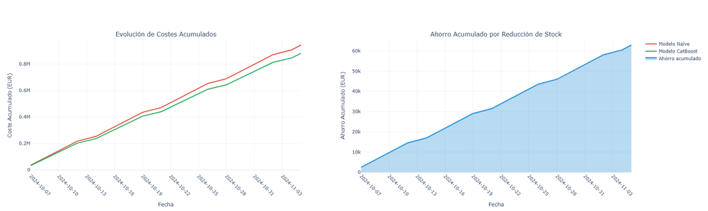

```python
import plotly.graph_objects as go
from plotly.subplots import make_subplots

# Subplots: solo costes acumulados y ahorro acumulado
fig = make_subplots(rows=1, cols=2, subplot_titles=(
    "Evolución de Costes Acumulados",
    "Ahorro Acumulado por Reducción de Stock"
))

# Costes acumulados
fig.add_trace(
    go.Scatter(
        x=df_diario['fecha'],
        y=df_diario['coste_acumulado_Naive'],
        mode='lines',
        name='Modelo Naive',
        line=dict(color='#e74c3c', width=2.5),
        hovertemplate='%{x|%Y-%m-%d}<br>Coste Naive: %{y:,.0f} EUR<extra></extra>'
    ),
    row=1, col=1
 )
fig.add_trace(
    go.Scatter(
        x=df_diario['fecha'],
        y=df_diario['coste_acumulado_CatBoost'],
        mode='lines',
        name='Modelo CatBoost',
        line=dict(color='#27ae60', width=2.5),
        hovertemplate='%{x|%Y-%m-%d}<br>Coste CatBoost: %{y:,.0f} EUR<extra></extra>'
    ),
    row=1, col=1
 )

# Ahorro acumulado
fig.add_trace(
    go.Scatter(
        x=df_diario['fecha'],
        y=df_diario['ahorro_acumulado'],
        mode='lines',
        name='Ahorro acumulado',
        line=dict(color='#3498db', width=3),
        fill='tozeroy',
        fillcolor='rgba(52, 152, 219, 0.35)',
        hovertemplate='%{x|%Y-%m-%d}<br>Ahorro acumulado: %{y:,.0f} EUR<extra></extra>'
    ),
    row=1, col=2
 )

# Layout
fig.update_layout(
    height=550, width=1200,
    showlegend=True,
    legend_title_text='',
    template='plotly_white'
 )

# Ejes
fig.update_xaxes(title_text='Fecha', tickformat='%Y-%m-%d', tickangle=45)
fig.update_yaxes(title_text='Coste Acumulado (EUR)', row=1, col=1, separatethousands=True)
fig.update_yaxes(title_text='Ahorro Acumulado (EUR)', row=1, col=2, separatethousands=True)

fig.show()
```

# Tabla Resumen Comparativa

```python
# Calcular variables para la tabla resumen
coste_total_naive = df_diario['coste_acumulado_Naive'].iloc[-1]
coste_total_catboost = df_diario['coste_acumulado_CatBoost'].iloc[-1]
ahorro_total = df_diario['ahorro_acumulado'].iloc[-1]
dias_en_periodo = len(df_diario)
factor_anualizacion = 365 / dias_en_periodo

# Calcular reducción promedio de stock (filtrando valores válidos)
reduccion_stock_promedio = df_test[df_test['stock_seguridad_Naive'] > 0]['reduccion_stock_%'].mean()

# Crear tabla resumen final
resumen = pd.DataFrame({
    'Métrica': [
        'RMSE Promedio (unidades)',
        'Stock Seguridad Promedio (unidades)',
        'Valor Stock Promedio (€)',
        'Coste Diario Promedio (€)',
        'Coste Total Periodo (€)',
        'Ahorro Total Periodo (€)',
        'Ahorro Anual Proyectado (€)',
        'Reducción Stock (%)',
        'Reducción Costes (%)'
    ],
    'Modelo Naive': [
        f"{rmse_por_producto['RMSE_Naive'].mean():.2f}",
        f"{df_test['stock_seguridad_Naive'].mean():.2f}",
        f"{df_test['valor_stock_Naive'].mean():.2f}",
        f"{df_test['coste_stock_dia_Naive'].mean():.2f}",
        f"{coste_total_naive:,.2f}",
        '-',
        '-',
        '-',
        '-'
    ],
    'Modelo CatBoost': [
        f"{rmse_por_producto['RMSE_CatBoost'].mean():.2f}",
        f"{df_test['stock_seguridad_CatBoost'].mean():.2f}",
        f"{df_test['valor_stock_CatBoost'].mean():.2f}",
        f"{df_test['coste_stock_dia_CatBoost'].mean():.2f}",
        f"{coste_total_catboost:,.2f}",
        f"{ahorro_total:,.2f}",
        f"{ahorro_total * factor_anualizacion:,.2f}",
        f"{reduccion_stock_promedio:.2f}%",
        f"{(ahorro_total/coste_total_naive*100):.2f}%"
    ]
})

print("\n" + "=" * 100)
print("TABLA RESUMEN: COMPARATIVA MODELO NAIVE vs CATBOOST")
print("=" * 100)
display(resumen)

# Información adicional
print("\n" + "=" * 100)
print("PARÁMETROS UTILIZADOS")
print("=" * 100)
print(f"• Nivel de servicio: {NIVEL_SERVICIO*100}%")
print(f"• Factor Z (Z-score): {Z_SCORE:.3f}")
print(f"• Porcentaje a aplicar al coste unitario: {TASA_ALMACENAMIENTO*100}%")
print(f"• Periodo analizado: {df_test['fecha'].min().strftime('%Y-%m-%d')} a {df_test['fecha'].max().strftime('%Y-%m-%d')}")
print(f"• Días en el periodo: {dias_en_periodo}")
print(f"• Número de productos: {df_test['producto'].nunique()}")
print(f"• Total de observaciones: {len(df_test):,}")
```

```
====================================================================================================
TABLA RESUMEN: COMPARATIVA MODELO NAIVE vs CATBOOST
====================================================================================================
```

|  | Métrica | Modelo Naive | Modelo CatBoost |
| --- | --- | --- | --- |
| 0 | RMSE Promedio (unidades) | 2.14 | 2.03 |
| 1 | Stock Seguridad Promedio (unidades) | 15.56 | 14.72 |
| 2 | Valor Stock Promedio (€) | 812.36 | 758.23 |
| 3 | Coste Diario Promedio (€) | 40.62 | 37.91 |
| 4 | Coste Total Periodo (€) | 944,124.06 | 881,212.93 |
| 5 | Ahorro Total Periodo (€) | - | 62,911.13 |
| 6 | Ahorro Anual Proyectado (€) | - | 883,175.45 |
| 7 | Reducción Stock (%) | - | 5.01% |
| 8 | Reducción Costes (%) | - | 6.66% |

```
====================================================================================================
PARÁMETROS UTILIZADOS
====================================================================================================
• Nivel de servicio: 95.0%
• Factor Z (Z-score): 1.645
• Porcentaje a aplicar al coste unitario: 5.0%
• Periodo analizado: 2024-10-07 a 2024-11-05
• Días en el periodo: 26
• Número de productos: 894
• Total de observaciones: 23,244
```

# Análisis por Producto

```python
# Agregar costes por producto
df_por_producto = df_test.groupby('producto').agg({
    'eurPrecioMedio': 'first',
    'ciclo_aprovisionamiento': 'first',
    'RMSE_CatBoost': 'first',
    'RMSE_Naive': 'first',
    'stock_seguridad_CatBoost': 'first',
    'stock_seguridad_Naive': 'first',
    'coste_stock_dia_CatBoost': 'sum',
    'coste_stock_dia_Naive': 'sum',
    'ahorro_diario_euros': 'sum'
}).reset_index()

# Calcular porcentajes con protección contra división por cero
df_por_producto['mejora_RMSE_%'] = np.where(
    df_por_producto['RMSE_Naive'] == 0,
    0,
    (df_por_producto['RMSE_Naive'] - df_por_producto['RMSE_CatBoost']) / df_por_producto['RMSE_Naive'] * 100
)

df_por_producto['reduccion_stock_%'] = np.where(
    df_por_producto['stock_seguridad_Naive'] == 0,
    0,
    (df_por_producto['stock_seguridad_Naive'] - df_por_producto['stock_seguridad_CatBoost']) / df_por_producto['stock_seguridad_Naive'] * 100
)

df_por_producto['ahorro_%'] = np.where(
    df_por_producto['coste_stock_dia_Naive'] == 0,
    0,
    df_por_producto['ahorro_diario_euros'] / df_por_producto['coste_stock_dia_Naive'] * 100
)

# Renombrar columnas para mejor visualización
df_por_producto.columns = [
    'Producto', 'Precio (€)', 'Ciclo Aprov. (días)',
    'RMSE CatBoost', 'RMSE Naive',
    'Stock Segur. CatBoost', 'Stock Segur. Naive',
    'Coste Total CatBoost (€)', 'Coste Total Naive (€)',
    'Ahorro Total (€)', 'Mejora RMSE (%)',
    'Reducción Stock (%)', 'Ahorro (%)'
]

# Ordenar por ahorro
df_por_producto = df_por_producto.sort_values('Ahorro Total (€)', ascending=False)

print("\n" + "=" * 100)
print("ANÁLISIS DETALLADO POR PRODUCTO")
print("=" * 100)
display(df_por_producto)
```

```
====================================================================================================
ANÁLISIS DETALLADO POR PRODUCTO
====================================================================================================
```

|  | Producto | Precio (€) | Ciclo Aprov. (días) | RMSE CatBoost | RMSE Naive | Stock Segur. CatBoost | Stock Segur. Naive | Coste Total CatBoost (€) | Coste Total Naive (€) | Ahorro Total (€) | Mejora RMSE (%) | Reducción Stock (%) | Ahorro (%) |
| --- | --- | --- | --- | --- | --- | --- | --- | --- | --- | --- | --- | --- | --- |
| 505 | 572 | 625.260000 | 16 | 4.294293 | 4.801745 | 28.253935 | 31.592671 | 22965.872075 | 25679.723736 | 2713.851661 | 10.568072 | 10.568072 | 10.568072 |
| 2 | 3 | 169.000000 | 29 | 5.331253 | 6.600565 | 47.223213 | 58.466535 | 10374.939789 | 12845.097832 | 2470.158043 | 19.230356 | 19.230356 | 19.230356 |
| 76 | 85 | 189.996667 | 29 | 4.250378 | 5.107184 | 37.649030 | 45.238457 | 9299.147241 | 11173.702830 | 1874.555589 | 16.776494 | 16.776494 | 16.776494 |
| 127 | 144 | 97.040000 | 29 | 4.996389 | 6.614030 | 44.257052 | 58.585810 | 5583.115615 | 7390.717137 | 1807.601522 | 24.457728 | 24.457728 | 24.457728 |
| 260 | 289 | 323.500000 | 16 | 3.554628 | 4.058017 | 23.387373 | 26.699376 | 9835.559784 | 11228.422389 | 1392.862605 | 12.404793 | 12.404793 | 12.404793 |
| ... | ... | ... | ... | ... | ... | ... | ... | ... | ... | ... | ... | ... | ... |
| 388 | 438 | 177.462000 | 18 | 0.577515 | 0.000000 | 4.030205 | 0.000000 | 929.770725 | 0.000000 | -929.770725 | 0.000000 | 0.000000 | 0.000000 |
| 738 | 835 | 189.000000 | 20 | 0.557590 | 0.000000 | 4.101635 | 0.000000 | 1007.771811 | 0.000000 | -1007.771811 | 0.000000 | 0.000000 | 0.000000 |
| 728 | 820 | 257.470000 | 16 | 0.525250 | 0.000000 | 3.455840 | 0.000000 | 1156.707782 | 0.000000 | -1156.707782 | 0.000000 | 0.000000 | 0.000000 |
| 242 | 270 | 387.350000 | 9 | 0.594800 | 0.000000 | 2.935076 | 0.000000 | 1477.972038 | 0.000000 | -1477.972038 | 0.000000 | 0.000000 | 0.000000 |
| 742 | 839 | 438.900000 | 18 | 0.547891 | 0.000000 | 3.823469 | 0.000000 | 2181.556800 | 0.000000 | -2181.556800 | 0.000000 | 0.000000 | 0.000000 |

894 rows × 13 columns